# Project: No-Show Appointments Data Analysis

- Introduction
- Data Wrangling
- Exploratory Data Analysis
- Conclusions

## Introduction

### Dataset Description

Here, we'll be analyzing a dataset on hospital appointment records, and we'll be interested in finding trends that distinguish between patients who show up for the appointments they have scheduled and the ones who do not.

This dataset was derived as a result of data collected from a 100,000 Brazilian medical appointments made. The dataset focuses on whether or not patients turn up to their scheduled doctor visits. Every record contains some pieces of information about the patient. Each record consists of data from 14 columns: Patient ID, Appointment ID, Gender, Scheduled Day, Neighborhood, Appointment Day, Scholarship, Age, Hyper-tension, Diabetes, Alcoholism, Handicap, SMS_received, and No-show.

**Scheduled Day** indicates when the patient has scheduled their appointment.

**Neighbourhood** refers to the hospital's location.

**Scholarship** denotes whether or not the patient is registered in the Bolsa Famlia, a Brazilian welfare programme.

**No-show** reads 'No' if the patient turned up for their appointment, and 'Yes' if they did not.

### Question(s) for Analysis

> **Tip**: Clearly state one or more questions that you plan on exploring over the course of the report. You will address these questions in the **data analysis** and **conclusion** sections. Try to build your report around the analysis of at least one dependent variable and three independent variables. If you're not sure what questions to ask, then make sure you familiarize yourself with the dataset, its variables and the dataset context for ideas of what to explore.

> **Tip**: Once you start coding, use NumPy arrays, Pandas Series, and DataFrames where appropriate rather than Python lists and dictionaries. Also, **use good coding practices**, such as, define and use functions to avoid repetitive code. Use appropriate comments within the code cells, explanation in the mark-down cells, and meaningful variable names.

```python
#This cell is dedicated to importing the packages that will be used within this project: pandas, numpy, matplotlib, and seaborn.
#The latter is used to enhance the visualizations in the notebook!

import pandas as pd
import numpy as np
import seaborn as sns
import matplotlib.pyplot as plt
%matplotlib inline
```

```python
# Upgrade pandas to use dataframe.explode() function.
!pip install --upgrade pandas==0.25.0
```

## Data Wrangling

> **Tip**: In this section of the report, you will load in the data, check for cleanliness, and then trim and clean your dataset for analysis. Make sure that you **document your data cleaning steps in mark-down cells precisely and justify your cleaning decisions.**

### General Properties

> **Tip**: You should *not* perform too many operations in each cell. Create cells freely to explore your data. One option that you can take with this project is to do a lot of explorations in an initial notebook. These don't have to be organized, but make sure you use enough comments to understand the purpose of each code cell. Then, after you're done with your analysis, create a duplicate notebook where you will trim the excess and organize your steps so that you have a flowing, cohesive report.

```python
#Loading the No-Show Appointment dataset using pandas
df = pd.read_csv('noshowappointments-kagglev2-may-2016.csv')
df.head()
```

|  | PatientId | AppointmentID | Gender | ScheduledDay | AppointmentDay | Age | Neighbourhood | Scholarship | Hipertension | Diabetes | Alcoholism | Handcap | SMS_received | No-show |
| --- | --- | --- | --- | --- | --- | --- | --- | --- | --- | --- | --- | --- | --- | --- |
| 0 | 2.987250e+13 | 5642903 | F | 2016-04-29T18:38:08Z | 2016-04-29T00:00:00Z | 62 | JARDIM DA PENHA | 0 | 1 | 0 | 0 | 0 | 0 | No |
| 1 | 5.589978e+14 | 5642503 | M | 2016-04-29T16:08:27Z | 2016-04-29T00:00:00Z | 56 | JARDIM DA PENHA | 0 | 0 | 0 | 0 | 0 | 0 | No |
| 2 | 4.262962e+12 | 5642549 | F | 2016-04-29T16:19:04Z | 2016-04-29T00:00:00Z | 62 | MATA DA PRAIA | 0 | 0 | 0 | 0 | 0 | 0 | No |
| 3 | 8.679512e+11 | 5642828 | F | 2016-04-29T17:29:31Z | 2016-04-29T00:00:00Z | 8 | PONTAL DE CAMBURI | 0 | 0 | 0 | 0 | 0 | 0 | No |
| 4 | 8.841186e+12 | 5642494 | F | 2016-04-29T16:07:23Z | 2016-04-29T00:00:00Z | 56 | JARDIM DA PENHA | 0 | 1 | 1 | 0 | 0 | 0 | No |

```python
#How many rows and columns is this dataset made of?
df.shape
```

```
(110527, 14)
```

```python
#Let's see some summary statistics about the data in the columns.
df.describe()
```

|  | PatientId | AppointmentID | Age | Scholarship | Hipertension | Diabetes | Alcoholism | Handcap | SMS_received |
| --- | --- | --- | --- | --- | --- | --- | --- | --- | --- |
| count | 1.105270e+05 | 1.105270e+05 | 110527.000000 | 110527.000000 | 110527.000000 | 110527.000000 | 110527.000000 | 110527.000000 | 110527.000000 |
| mean | 1.474963e+14 | 5.675305e+06 | 37.088874 | 0.098266 | 0.197246 | 0.071865 | 0.030400 | 0.022248 | 0.321026 |
| std | 2.560949e+14 | 7.129575e+04 | 23.110205 | 0.297675 | 0.397921 | 0.258265 | 0.171686 | 0.161543 | 0.466873 |
| min | 3.921784e+04 | 5.030230e+06 | -1.000000 | 0.000000 | 0.000000 | 0.000000 | 0.000000 | 0.000000 | 0.000000 |
| 25% | 4.172614e+12 | 5.640286e+06 | 18.000000 | 0.000000 | 0.000000 | 0.000000 | 0.000000 | 0.000000 | 0.000000 |
| 50% | 3.173184e+13 | 5.680573e+06 | 37.000000 | 0.000000 | 0.000000 | 0.000000 | 0.000000 | 0.000000 | 0.000000 |
| 75% | 9.439172e+13 | 5.725524e+06 | 55.000000 | 0.000000 | 0.000000 | 0.000000 | 0.000000 | 0.000000 | 1.000000 |
| max | 9.999816e+14 | 5.790484e+06 | 115.000000 | 1.000000 | 1.000000 | 1.000000 | 1.000000 | 4.000000 | 1.000000 |

### Data Cleaning

The column names do not follow python's naming conventions. Python's naming conventions dictate all lowercase with using an underscore as a separator between two words. Let's fix that!

```python
df.rename(columns = {'PatientId': 'patient_id', 'AppointmentID': 'appointment_id', 'Gender': 'gender', 'ScheduledDay': 'scheduled_day', 'AppointmentDay': 'appointment_day', 'Age': 'age', 'Neighbourhood': 'neighborhood', 'Scholarship': 'scholarship', 'Hipertension': 'hyper_tension', 'Diabetes': 'diabetes', 'Alcoholism': 'alcoholism', 'Handcap': 'handicap', 'SMS_received': 'sms_received', 'No-show': 'no_show'}, inplace = True)
```

## Now let's check to see if there are any missing data.

```python
df.info()
```

```
<class 'pandas.core.frame.DataFrame'>
RangeIndex: 110527 entries, 0 to 110526
Data columns (total 14 columns):
patient_id         110527 non-null float64
appointment_id     110527 non-null int64
gender             110527 non-null object
scheduled_day      110527 non-null object
appointment_day    110527 non-null object
age                110527 non-null int64
neighborhood       110527 non-null object
scholarship        110527 non-null int64
hyper_tension      110527 non-null int64
diabetes           110527 non-null int64
alcoholism         110527 non-null int64
handicap           110527 non-null int64
sms_received       110527 non-null int64
no_show            110527 non-null object
dtypes: float64(1), int64(8), object(5)
memory usage: 11.8+ MB
```

#### No null values found, great.

### Now let's check if there are any duplicated data.

```python
df.duplicated().sum()
```

```
0
```

#### No duplicated data found either.

### Let's take a look at the attribute datatypes.

```python
print(df.dtypes)
df.head(3)
```

```
patient_id         float64
appointment_id       int64
gender              object
scheduled_day       object
appointment_day     object
age                  int64
neighborhood        object
scholarship          int64
hyper_tension        int64
diabetes             int64
alcoholism           int64
handicap             int64
sms_received         int64
no_show             object
dtype: object
```

|  | patient_id | appointment_id | gender | scheduled_day | appointment_day | age | neighborhood | scholarship | hyper_tension | diabetes | alcoholism | handicap | sms_received | no_show |
| --- | --- | --- | --- | --- | --- | --- | --- | --- | --- | --- | --- | --- | --- | --- |
| 0 | 2.987250e+13 | 5642903 | F | 2016-04-29T18:38:08Z | 2016-04-29T00:00:00Z | 62 | JARDIM DA PENHA | 0 | 1 | 0 | 0 | 0 | 0 | No |
| 1 | 5.589978e+14 | 5642503 | M | 2016-04-29T16:08:27Z | 2016-04-29T00:00:00Z | 56 | JARDIM DA PENHA | 0 | 0 | 0 | 0 | 0 | 0 | No |
| 2 | 4.262962e+12 | 5642549 | F | 2016-04-29T16:19:04Z | 2016-04-29T00:00:00Z | 62 | MATA DA PRAIA | 0 | 0 | 0 | 0 | 0 | 0 | No |

# 'patient_id' column should be an integer instead of a float, and I'd rather have 'scheduled_day' and 'appointment_day' in date format rather than a string. Let's fix that.

```python
df['patient_id'] = df['patient_id'].astype(int)
```

```python
df['appointment_day'] = pd.to_datetime(df['appointment_day'])
df['scheduled_day'] = pd.to_datetime(df['scheduled_day'])
df.dtypes
```

```
patient_id                       int64
appointment_id                   int64
gender                          object
scheduled_day      datetime64[ns, UTC]
appointment_day    datetime64[ns, UTC]
age                              int64
neighborhood                    object
scholarship                      int64
hyper_tension                    int64
diabetes                         int64
alcoholism                       int64
handicap                         int64
sms_received                     int64
no_show                         object
dtype: object
```

### Great! Now, we have the right data types, let's move on to check other stuff.

I'd like to extract the day, month from the 'scheduled_day' and 'appointment_day' columns, making 4 extra columns: sch_day, sch_month, app_day, app_month and let's rename the 'scheduled_day' and 'appointment_month' into 'scheduling_date' and 'appointment_date' to make it more readable.

I suspect that there could be a correlation between appointments scheduled too far in the future and missed appointments, but again, we'll see if that's true soon!

```python
df.rename(columns = {'scheduled_day': 'scheduling_date', 'appointment_day': 'appointment_date'}, inplace = True)
df.head(1)
```

|  | patient_id | appointment_id | gender | scheduling_date | appointment_date | age | neighborhood | scholarship | hyper_tension | diabetes | alcoholism | handicap | sms_received | no_show |
| --- | --- | --- | --- | --- | --- | --- | --- | --- | --- | --- | --- | --- | --- | --- |
| 0 | 29872499824296 | 5642903 | F | 2016-04-29 18:38:08+00:00 | 2016-04-29 00:00:00+00:00 | 62 | JARDIM DA PENHA | 0 | 1 | 0 | 0 | 0 | 0 | No |

```python
df['sch_day'] = df.scheduling_date.dt.day
```

```python
df['sch_month'] = df.scheduling_date.dt.month
```

```python
df['app_day'] = df.appointment_date.dt.day
```

```python
df['app_month'] = df.appointment_date.dt.month
```

```python
df.info()
```

```
<class 'pandas.core.frame.DataFrame'>
RangeIndex: 110527 entries, 0 to 110526
Data columns (total 18 columns):
patient_id          110527 non-null int64
appointment_id      110527 non-null int64
gender              110527 non-null object
scheduling_date     110527 non-null datetime64[ns, UTC]
appointment_date    110527 non-null datetime64[ns, UTC]
age                 110527 non-null int64
neighborhood        110527 non-null object
scholarship         110527 non-null int64
hyper_tension       110527 non-null int64
diabetes            110527 non-null int64
alcoholism          110527 non-null int64
handicap            110527 non-null int64
sms_received        110527 non-null int64
no_show             110527 non-null object
sch_day             110527 non-null int64
sch_month           110527 non-null int64
app_day             110527 non-null int64
app_month           110527 non-null int64
dtypes: datetime64[ns, UTC](2), int64(13), object(3)
memory usage: 15.2+ MB
```

### Great! Now that we've got our data types in check, let's check on the values of the attributes.

I'm curious about whether there could be several records for each patient ID, let's check.

```python
df['patient_id'].value_counts()
```

```
822145925426128    88
99637671331        84
26886125921145     70
33534783483176     65
6264198675331      62
                   ..
2886912523138       1
68129842443312      1
99264711372         1
2212945531847       1
57863365759569      1
Name: patient_id, Length: 62299, dtype: int64
```

So, as suspected, there **are** several records for each patient ID, which might serve our purpose for finding trends. Maybe if a specific patient makes an appointment and he's constantly not showing up for his past appointment, it could lead to a higher probability that he won't attend to his next appointment either. So I'll leave the 'patient_id' column because maybe some patients are not showing up to appointments not because of an illness or living in a far neighborhood, but just because it implies a personality trait of irresponsibility. Again, this is just a hunch, so I'll leave the 'patient_id' column and check my theory later!

### Let's take a look at the values of each column, in order to find if there are any fake data.

```python
df['gender'].value_counts()
```

```
F    71840
M    38687
Name: gender, dtype: int64
```

```python
df['age'].value_counts()
```

```
 0      3539
 1      2273
 52     1746
 49     1652
 53     1651
        ...
 115       5
 100       4
 102       2
 99        1
-1         1
Name: age, Length: 104, dtype: int64
```

This seems weird. 'age' has values ranging from -1 to 115.. This doesn't seem real. Also, the age zero is the most popular age in the dataset. I'm not sure if this means an infant, let's check if there's further documentation.

```python
df['scholarship'].value_counts()
```

```
0    99666
1    10861
Name: scholarship, dtype: int64
```

```python
df['hyper_tension'].value_counts()
```

```
0    88726
1    21801
Name: hyper_tension, dtype: int64
```

```python
df['diabetes'].value_counts()
```

```
0    102584
1      7943
Name: diabetes, dtype: int64
```

```python
df['alcoholism'].value_counts()
```

```
0    107167
1      3360
Name: alcoholism, dtype: int64
```

```python
df['handicap'].value_counts()
```

```
0    108286
1      2042
2       183
3        13
4         3
Name: handicap, dtype: int64
```

Also weird. I don't know what these numbers stand for. This needs further researching.

```python
df['sms_received'].value_counts()
```

```
0    75045
1    35482
Name: sms_received, dtype: int64
```

```python
df['no_show'].value_counts()
```

```
No     88208
Yes    22319
Name: no_show, dtype: int64
```

```python
df.describe()
```

|  | patient_id | appointment_id | age | scholarship | hyper_tension | diabetes | alcoholism | handicap | sms_received | sch_day | sch_month | app_day | app_month |
| --- | --- | --- | --- | --- | --- | --- | --- | --- | --- | --- | --- | --- | --- |
| count | 1.105270e+05 | 1.105270e+05 | 110527.000000 | 110527.000000 | 110527.000000 | 110527.000000 | 110527.000000 | 110527.000000 | 110527.000000 | 110527.000000 | 110527.000000 | 110527.000000 | 110527.000000 |
| mean | 1.474963e+14 | 5.675305e+06 | 37.088874 | 0.098266 | 0.197246 | 0.071865 | 0.030400 | 0.022248 | 0.321026 | 14.252228 | 4.823871 | 12.499398 | 5.210048 |
| std | 2.560949e+14 | 7.129575e+04 | 23.110205 | 0.297675 | 0.397921 | 0.258265 | 0.171686 | 0.161543 | 0.466873 | 9.345629 | 0.715801 | 9.056482 | 0.473780 |
| min | 3.921700e+04 | 5.030230e+06 | -1.000000 | 0.000000 | 0.000000 | 0.000000 | 0.000000 | 0.000000 | 0.000000 | 1.000000 | 1.000000 | 1.000000 | 4.000000 |
| 25% | 4.172614e+12 | 5.640286e+06 | 18.000000 | 0.000000 | 0.000000 | 0.000000 | 0.000000 | 0.000000 | 0.000000 | 6.000000 | 4.000000 | 5.000000 | 5.000000 |
| 50% | 3.173184e+13 | 5.680573e+06 | 37.000000 | 0.000000 | 0.000000 | 0.000000 | 0.000000 | 0.000000 | 0.000000 | 13.000000 | 5.000000 | 10.000000 | 5.000000 |
| 75% | 9.439172e+13 | 5.725524e+06 | 55.000000 | 0.000000 | 0.000000 | 0.000000 | 0.000000 | 0.000000 | 1.000000 | 22.000000 | 5.000000 | 19.000000 | 5.000000 |
| max | 9.999816e+14 | 5.790484e+06 | 115.000000 | 1.000000 | 1.000000 | 1.000000 | 1.000000 | 4.000000 | 1.000000 | 31.000000 | 12.000000 | 31.000000 | 6.000000 |

The minimum of age is -1 which doesn't make sense. The maximum though is 115 which is not probable but possible. I'll drop the rows with 'age' = -1 because this is definitely data misgathered, and leave the 'age' =115 as is because there's a probability it's real.

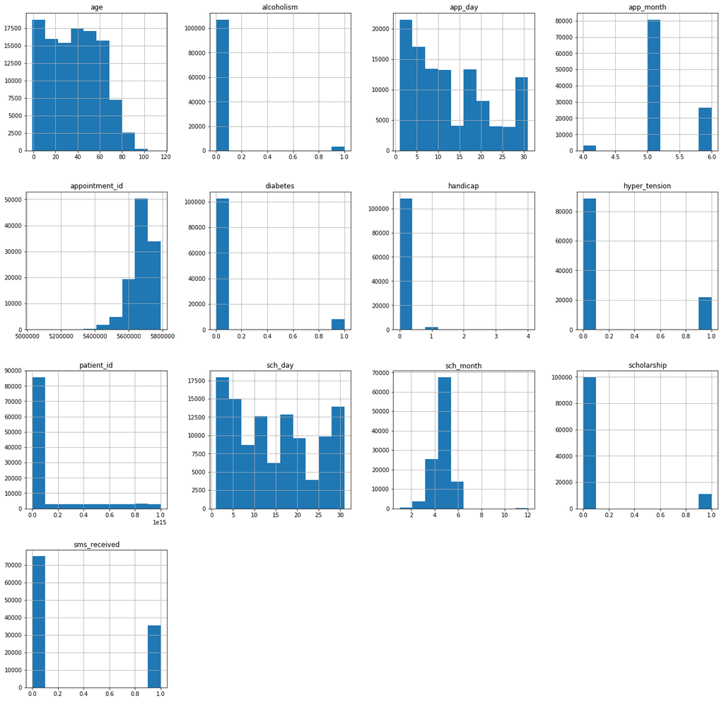

```python
#Let's get more elaborate descriptions on the dataset through a thorough histogram check!
df.hist(figsize = (22,22));
```

```python
#Dropping the row where age equals -1
df = df[df.age != -1]
```

```python
#Checking if it worked
df[df.age == -1 ]
```

|  | patient_id | appointment_id | gender | scheduling_date | appointment_date | age | neighborhood | scholarship | hyper_tension | diabetes | alcoholism | handicap | sms_received | no_show | sch_day | sch_month | app_day | app_month |
| --- | --- | --- | --- | --- | --- | --- | --- | --- | --- | --- | --- | --- | --- | --- | --- | --- | --- | --- |

I don't think the 'appointment_id' column will be of any benefit in our analysis so I'll just drop it.

```python
df.drop('appointment_id', axis = 1, inplace = True)
```

### Great, now that we cleaned our data, we're ready to go to analysis!

## Exploratory Data Analysis

> **Tip**: Now that you've trimmed and cleaned your data, you're ready to move on to exploration. **Compute statistics** and **create visualizations** with the goal of addressing the research questions that you posed in the Introduction section. You should compute the relevant statistics throughout the analysis when an inference is made about the data. Note that at least two or more kinds of plots should be created as part of the exploration, and you must compare and show trends in the varied visualizations.

> **Tip**: - Investigate the stated question(s) from multiple angles. It is recommended that you be systematic with your approach. Look at one variable at a time, and then follow it up by looking at relationships between variables. You should explore at least three variables in relation to the primary question. This can be an exploratory relationship between three variables of interest, or looking at how two independent variables relate to a single dependent variable of interest. Lastly, you should perform both single-variable (1d) and multiple-variable (2d) explorations.

# Main Research Question:

# What criteria should we be aware of in order to forecast whether or not a patient will make an appearance for their planned appointment?

In order to answer this question we have to look into the effect of each independent variable on the action of missing appointment, these independent variables that we'll look into are:

1. Patient Specific Charachteristics ('patient_id')
2. Age ('age')
3. Alcoholism ('alcoholism')
4. Diabetes ('diabetes')
5. Handicap ('handicap')
6. Hypertension ('hyper_tension')
7. Scholarship ('scholarship')
8. Whether a Reminding Text Message was Sent ('sms_received')
9. Time Separating the Date of Scheduling the Appointment and the Appointment Date

## How does the independent variable Patient Specific Charachteristics (irresponsibility/punctuality) affect the dependent variable of showing up?

```python
#Let's first create a mask for the patients who showed up and those who didn't to make the exploration easier!
#This is a mask that will be used to easily access all the patients who turned up to theri scheduled appointments.

turned_up = df.no_show == 'No'
```

```python
#This is a mask that will be used to easily access all the patients who did NOT turn up to theri scheduled appointments.

no_turn_up = df.no_show == 'Yes'
```

Cool! Now let's start seeing patterns.

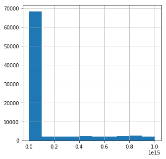

```python
#Let's see the count of people who showed up vs. their patient_id (personality)
df.patient_id[turned_up].hist(figsize = (5,5));
```

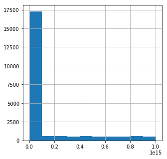

```python
#Let's see the count of people who did not show up vs. their patient_id (personality)
df.patient_id[no_turn_up].hist(figsize = (5,5));
```

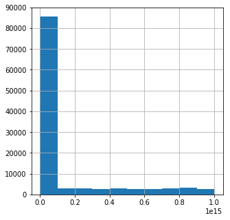

```python
#Let's try the count of all patients vs. their patient_id (personality), to compare that to the past 2 histograms.
df.patient_id.hist(figsize = (5,5))
```

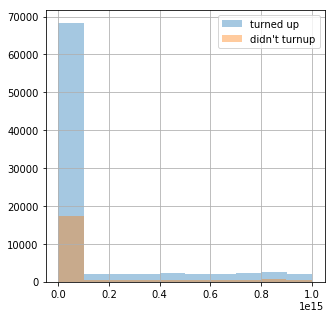

```python
#What about seeing both of these histograms in the same graph?
df.patient_id[turned_up].hist(alpha = 0.4, figsize = (5,5), label = 'turned up');
df.patient_id[no_turn_up].hist(alpha = 0.4, figsize = (5,5), label = "didn't turnup");
plt.legend()
```

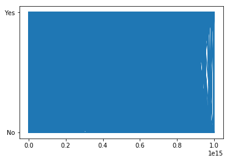

```python
#We could try to see if there's any relationship between them by getting an old fashioned plot.
plt.plot(df['patient_id'], df['no_show'])
```

This was inconclusive. I guess that's because we'd need data that featured a more finite set of patients.. But for the current dataset, no correlation was found between patient_id's and whether or not they had showed up.

## How does the independent variable age affect the dependent variable of showing up?

Let's see some statistics about age in both categories: the patients who showed up and those who didn't.

```python
df.age[turned_up].describe()
```

```
count    88207.000000
mean        37.790504
std         23.338645
min          0.000000
25%         18.000000
50%         38.000000
75%         56.000000
max        115.000000
Name: age, dtype: float64
```

```python
df.age[no_turn_up].describe()
```

```
count    22319.000000
mean        34.317667
std         21.965941
min          0.000000
25%         16.000000
50%         33.000000
75%         51.000000
max        115.000000
Name: age, dtype: float64
```

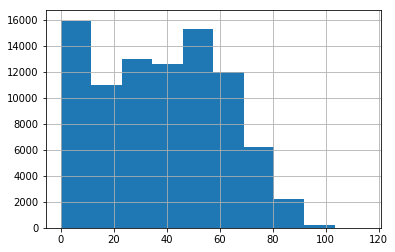

```python
#Let's see the count of people who showed up vs. their age.
df.age[turned_up].hist()
```

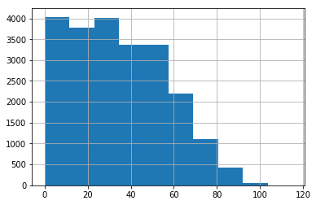

```python
#Let's see the count of people who didn't show up vs. their age.
df.age[no_turn_up].hist()
```

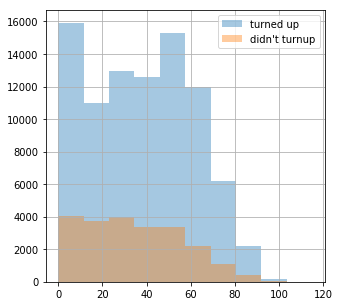

```python
#What about seeing both of these histograms in the same graph?
df.age[turned_up].hist(alpha = 0.4, figsize = (5,5), label = 'turned up');
df.age[no_turn_up].hist(alpha = 0.4, figsize = (5,5), label = "didn't turnup");
plt.legend()
```

The statistics look very similar. I'd like to see a representation of the ratio of how often each specific age shows up, or doesn't.

```
Text(0.5,1,'Figure 1')
```

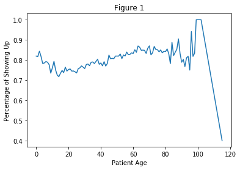

```python
#first, we split the dataset by the 'turned_up' mask which gives us a separate dataframe that only consists of-
#- the patients who showed up.
#Second, we split them into groups charachterized by age, then get the counts for each age group.
#Finally, we divide those counts with the total number of samples (of those who showed up and those who didn't),
#to get a normalized ratio!

age_ratio_turnup = df[turned_up].groupby(['age']).size()/df.groupby(['age']).size()
plt.plot(age_ratio_turnup)
plt.xlabel('Patient Age')
plt.ylabel('Percentage of Showing Up')
plt.title('Figure 1')
```

```
Text(0.5,1,'Figure 2')
```

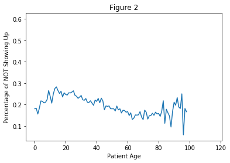

```python
age_ratio_noturnup = df[no_turn_up].groupby(['age']).size()/df.groupby(['age']).size()
plt.plot(age_ratio_noturnup)
plt.xlabel('Patient Age')
plt.ylabel('Percentage of NOT Showing Up')
plt.title('Figure 2')
```

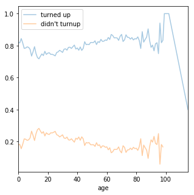

```python
#What about seeing both of these graphs in the same graph?
age_ratio_turnup.plot(alpha = 0.4, figsize = (5,5), label = 'turned up');
age_ratio_noturnup.plot(alpha = 0.4, figsize = (5,5), label = "didn't turnup");
plt.legend();
```

## How does the independent variable Alcoholism affect the dependent variable of Showing Up?

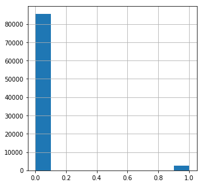

```python
#Let's see the count of people who showed up vs. whether they suffered from alcoholism or not.
df.alcoholism[turned_up].hist(figsize = (5,5));
```

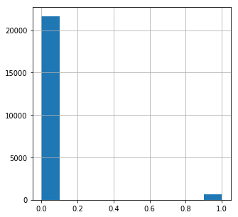

```python
#Let's see the count of people who did not show up vs. whether they suffered from alcoholism or not.
df.alcoholism[no_turn_up].hist(figsize = (5,5));
```

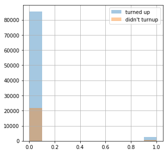

```python
#What about seeing both of these histograms in the same graph?
df.alcoholism[turned_up].hist(alpha = 0.4, figsize = (5,5), label = 'turned up');
df.alcoholism[no_turn_up].hist(alpha = 0.4, figsize = (5,5), label = "didn't turnup");
plt.legend();
```

```
Text(0.5,1,'Percentage of Patients Showing Up in Reference to Whether They Suffer from Alcoholism')
```

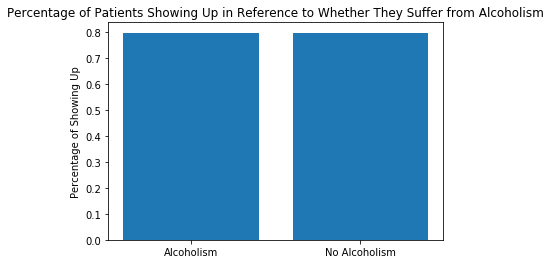

```python
#first, we split the dataset by the 'turned_up' mask which gives us a separate dataframe that only consists of-
#- the patients who showed up.
#Second, we split them into groups charachterized by whether they're suffering from alcoholism or not, then get the counts for each group.
#Finally, we divide those counts with the total number of samples (of those who showed up and those who didn't),
#to get a normalized ratio!

alcoholism_ratio_turnup = df[turned_up].groupby(['alcoholism']).size()/df.groupby(['alcoholism']).size()
index = ['No Alcoholism', 'Alcoholism']
height = alcoholism_ratio_turnup[1]
plt.bar(index, height)
plt.ylabel('Percentage of Showing Up')
plt.title('Percentage of Patients Showing Up in Reference to Whether They Suffer from Alcoholism')
```

```
Text(0.5,1,'Percentage of Patients Not Showing Up in Reference to Whether They Suffer from Alcoholism')
```

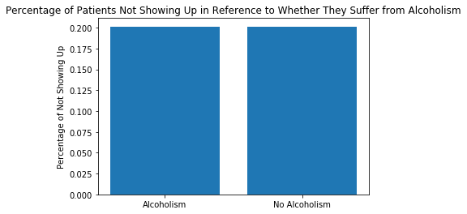

```python
#first, we split the dataset by the 'turned_up' mask which gives us a separate dataframe that only consists of-
#- the patients who showed up.
#Second, we split them into groups charachterized by whether they're suffering from alcoholism or not, then get the counts for each group.
#Finally, we divide those counts with the total number of samples (of those who showed up and those who didn't),
#to get a normalized ratio!

alcoholism_ratio_no_turnup = df[no_turn_up].groupby(['alcoholism']).size()/df.groupby(['alcoholism']).size()
index = ['No Alcoholism', 'Alcoholism']
height = alcoholism_ratio_no_turnup[1]
plt.bar(index, height)
plt.ylabel('Percentage of Not Showing Up')
plt.title('Percentage of Patients Not Showing Up in Reference to Whether They Suffer from Alcoholism')
```

There seems to be no correlation between alcoholism and the dependent variable of not showing up.

## How does the independent variable Diabetes affect the dependent variable of showing up?

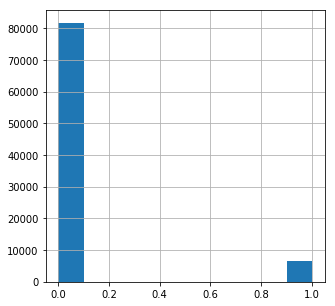

```python
#Let's see the count of people who showed up vs. whether they suffered from alcoholism or not.
df.diabetes[turned_up].hist(figsize = (5,5));
```

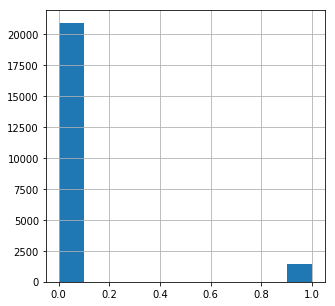

```python
#Let's see the count of people who did not show up vs. whether they suffered from diabtetes or not.
df.diabetes[no_turn_up].hist(figsize = (5,5));
```

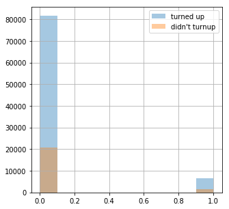

```python
#What about seeing both of these histograms in the same graph?
df.diabetes[turned_up].hist(alpha = 0.4, figsize = (5,5), label = 'turned up');
df.diabetes[no_turn_up].hist(alpha = 0.4, figsize = (5,5), label = "didn't turnup");
plt.legend();
```

```
Text(0.5,1,'Percentage of Patients Showing Up in Reference to Whether They Suffer from Diabetes')
```

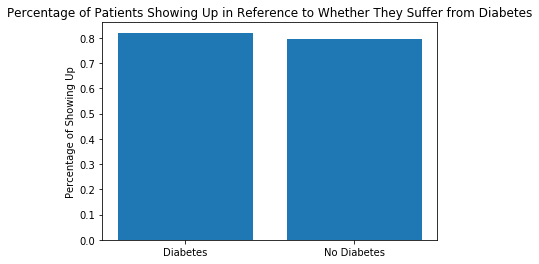

```python
#first, we split the dataset by the 'turned_up' mask which gives us a separate dataframe that only consists of-
#- the patients who showed up.
#Second, we split them into groups charachterized by whether they're suffering from diabetes or not, then get the counts for each group.
#Finally, we divide those counts with the total number of samples (of those who showed up and those who didn't),
#to get a normalized ratio!

diabetes_ratio_turnup = df[turned_up].groupby(['diabetes']).size()/df.groupby(['diabetes']).size()
index = ['No Diabetes', 'Diabetes']
height = diabetes_ratio_turnup
plt.bar(index, height)
plt.ylabel('Percentage of Showing Up')
plt.title('Percentage of Patients Showing Up in Reference to Whether They Suffer from Diabetes')
```

```
Text(0.5,1,'Percentage of Patients Not Showing Up in Reference to Whether They Suffer from Diabetes')
```

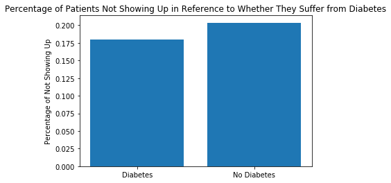

```python
#first, we split the dataset by the 'no_turn_up' mask which gives us a separate dataframe that only consists of-
#- the patients who did not show up.
#Second, we split them into groups charachterized by whether they're suffering from diabetes or not, then get the counts for each group.
#Finally, we divide those counts with the total number of samples (of those who showed up and those who didn't),
#to get a normalized ratio!

diabetes_ratio_no_turnup = df[no_turn_up].groupby(['diabetes']).size()/df.groupby(['diabetes']).size()
index = ['No Diabetes', 'Diabetes']
height = diabetes_ratio_no_turnup
plt.bar(index, height)
plt.ylabel('Percentage of Not Showing Up')
plt.title('Percentage of Patients Not Showing Up in Reference to Whether They Suffer from Diabetes')
```

## How does the independent variable Handicap affect the dependent variable of showing up?

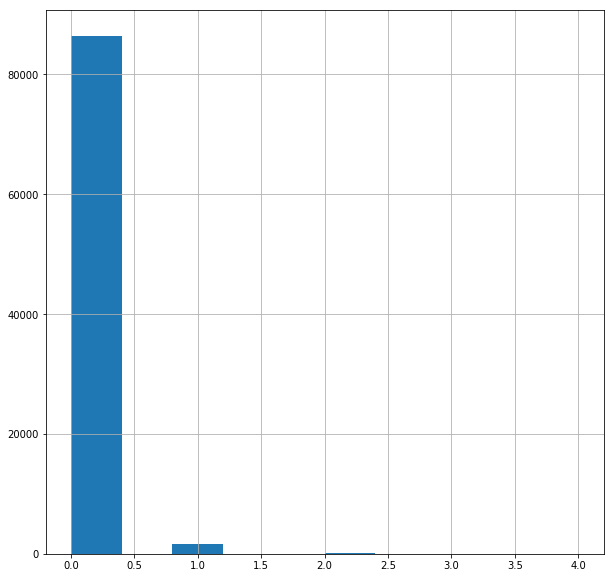

```python
#Let's see the count of people who showed up vs. whether they suffered from stage 1, 2, 3, 4 handicap or not.
df.handicap[turned_up].hist(figsize = (10,10));
```

```python
df.handicap[turned_up].value_counts()
```

```
0    86373
1     1676
2      146
3       10
4        2
Name: handicap, dtype: int64
```

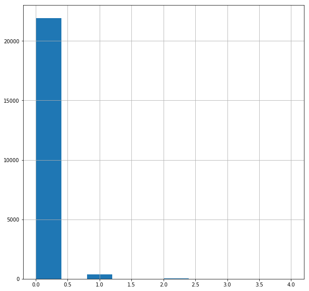

```python
#Let's see the count of people who did not show up vs. whether they suffered from from stage 1, 2, 3, 4 handicap or not.
df.handicap[no_turn_up].hist(figsize = (10,10));
```

```python
df.handicap[no_turn_up].value_counts()
```

```
0    21912
1      366
2       37
3        3
4        1
Name: handicap, dtype: int64
```

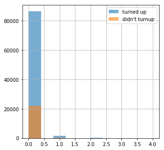

```python
#What about seeing both of these histograms in the same graph?
df.handicap[turned_up].hist(alpha = 0.6, figsize = (5,5), label = 'turned up');
df.handicap[no_turn_up].hist(alpha = 0.6, figsize = (5,5), label = "didn't turnup");
plt.legend();
```

```
Text(0.5,1,'Percentage of Patients Showing Up in Reference to Whether They Suffer from Handicap')
```

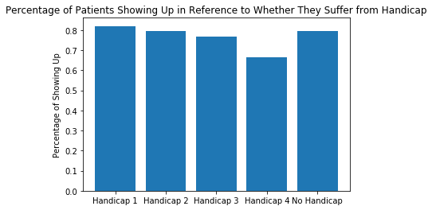

```python
#first, we split the dataset by the 'turned_up' mask which gives us a separate dataframe that only consists of-
#- the patients who showed up.
#Second, we split them into groups charachterized by whether they're suffering from either stages of handicap or not, then get the counts for each group.
#Finally, we divide those counts with the total number of samples (of those who showed up and those who didn't),
#to get a normalized ratio!

handicap_ratio_turnup = df[turned_up].groupby(['handicap']).size()/df.groupby(['handicap']).size()
index = ['No Handicap', 'Handicap 1', 'Handicap 2', 'Handicap 3', 'Handicap 4']
height = handicap_ratio_turnup
plt.bar(index, height)
plt.ylabel('Percentage of Showing Up')
plt.title('Percentage of Patients Showing Up in Reference to Whether They Suffer from Handicap')
```

```
Text(0.5,1,'Percentage of Patients Not Showing Up in Reference to Whether They Suffer from Handicap')
```

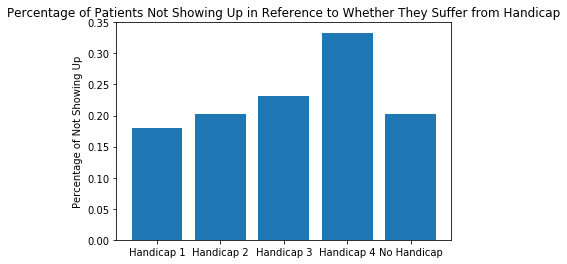

```python
#first, we split the dataset by the 'n_turn_up' mask which gives us a separate dataframe that only consists of-
#- the patients who did not show up.
#Second, we split them into groups charachterized by whether they're suffering from either stages of handicap or not, then get the counts for each group.
#Finally, we divide those counts with the total number of samples (of those who showed up and those who didn't),
#to get a normalized ratio!

handicap_ratio_no_turnup = df[no_turn_up].groupby(['handicap']).size()/df.groupby(['handicap']).size()
index = ['No Handicap', 'Handicap 1', 'Handicap 2', 'Handicap 3', 'Handicap 4']
height = handicap_ratio_no_turnup
plt.bar(index, height)
plt.ylabel('Percentage of Not Showing Up')
plt.title('Percentage of Patients Not Showing Up in Reference to Whether They Suffer from Handicap')
```

## How does the independent variable Hypertension affect the dependent variable of showing up?

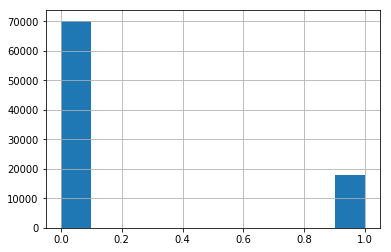

```python
#Let's see the count of people who showed up vs. whether they suffered from Hypertension or not.
df.hyper_tension[turned_up].hist();
```

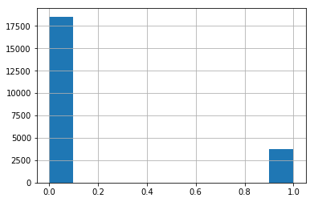

```python
#Let's see the count of people who did not show up vs. whether they suffered from Hypertension or not.
df.hyper_tension[no_turn_up].hist();
```

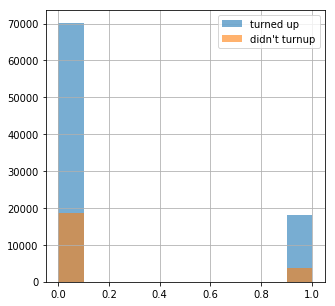

```python
#What about seeing both of these histograms in the same graph?
df.hyper_tension[turned_up].hist(alpha = 0.6, figsize = (5,5), label = 'turned up');
df.hyper_tension[no_turn_up].hist(alpha = 0.6, figsize = (5,5), label = "didn't turnup");
plt.legend();
```

```
Text(0.5,1,'Percentage of Patients Showing Up in Reference to Whether They Suffer from Hypertension')
```

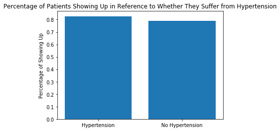

```python
#first, we split the dataset by the 'turned_up' mask which gives us a separate dataframe that only consists of-
#- the patients who showed up.
#Second, we split them into groups charachterized by whether they're suffering from hypertension or not, then get the counts for each group.
#Finally, we divide those counts with the total number of samples (of those who showed up and those who didn't),
#to get a normalized ratio!

hypertension_ratio_turnup = df[turned_up].groupby(['hyper_tension']).size()/df.groupby(['hyper_tension']).size()
index = ['No Hypertension', 'Hypertension']
height = hypertension_ratio_turnup
plt.bar(index, height)
plt.ylabel('Percentage of Showing Up')
plt.title('Percentage of Patients Showing Up in Reference to Whether They Suffer from Hypertension')
```

```
Text(0.5,1,'Percentage of Patients Not Showing Up in Reference to Whether They Suffer from Hypertension')
```

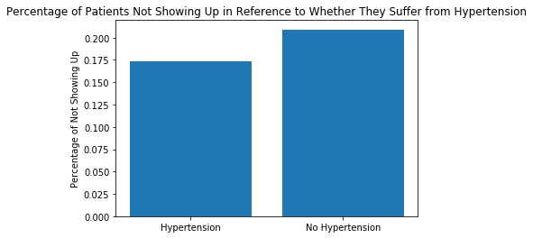

```python
#first, we split the dataset by the 'no_turn_up' mask which gives us a separate dataframe that only consists of-
#- the patients who did not show up.
#Second, we split them into groups charachterized by whether they're suffering from hypertension or not, then get the counts for each group.
#Finally, we divide those counts with the total number of samples (of those who showed up and those who didn't),
#to get a normalized ratio!

hypertension_ratio_no_turnup = df[no_turn_up].groupby(['hyper_tension']).size()/df.groupby(['hyper_tension']).size()
index = ['No Hypertension', 'Hypertension']
height = hypertension_ratio_no_turnup
plt.bar(index, height)
plt.ylabel('Percentage of Not Showing Up')
plt.title('Percentage of Patients Not Showing Up in Reference to Whether They Suffer from Hypertension')
```

There seems to be a correlation between patients who have hypertension and the dependent variable of showing up. The two figures above show that patients with hypertension have a higher probability of showing up to their scheduled appointments than those who don't.

## How does the independent variable Scholarship affect the dependent variable of showing up?

```
Text(0.5,0,'Whether a Patient was Granted a Scholarship')
```

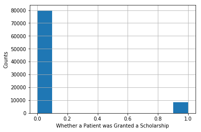

```python
#Let's see the count of people who showed up vs. whether they were granted a scholarship or not.
df.scholarship[turned_up].hist();
plt.ylabel('Counts')
plt.xlabel('Whether a Patient was Granted a Scholarship')
```

```
Text(0.5,0,'Whether a Patient was Granted a Scholarship')
```

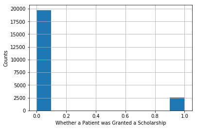

```python
#Let's see the count of people who did not show up vs. whether they suffered from Hypertension or not.
df.scholarship[no_turn_up].hist();
plt.ylabel('Counts')
plt.xlabel('Whether a Patient was Granted a Scholarship')
```

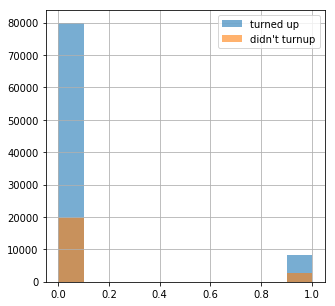

```python
#What about seeing both of these histograms in the same graph?
df.scholarship[turned_up].hist(alpha = 0.6, figsize = (5,5), label = 'turned up');
df.scholarship[no_turn_up].hist(alpha = 0.6, figsize = (5,5), label = "didn't turnup");
plt.legend();
```

```
Text(0.5,1,'Percentage of Patients Showing Up in Reference to Whether They were Granted a Scholarship')
```

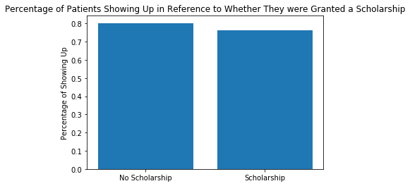

```python
#first, we split the dataset by the 'turned_up' mask which gives us a separate dataframe that only consists of-
#- the patients who showed up.
#Second, we split them into groups charachterized by whether they've been granted a scholarship or not, then get the counts for each group.
#Finally, we divide those counts with the total number of samples (of those who showed up and those who didn't),
#to get a normalized ratio!

scholarship_ratio_turnup = df[turned_up].groupby(['scholarship']).size()/df.groupby(['scholarship']).size()
index = ['No Scholarship', 'Scholarship']
height = scholarship_ratio_turnup
plt.bar(index, height)
plt.ylabel('Percentage of Showing Up')
plt.title('Percentage of Patients Showing Up in Reference to Whether They were Granted a Scholarship')
```

```
Text(0.5,1,'Percentage of Patients Not Showing Up in Reference to Whether They were Granted a Scholarship')
```

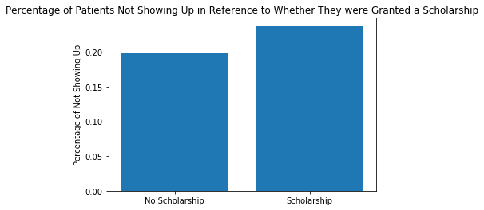

```python
#first, we split the dataset by the 'no_turn_up' mask which gives us a separate dataframe that only consists of-
#- the patients who did not show up.
#Second, we split them into groups charachterized by whether they've been granted a scholarship or not, then get the counts for each group.
#Finally, we divide those counts with the total number of samples (of those who showed up and those who didn't),
#to get a normalized ratio!

scholarship_ratio_no_turnup = df[no_turn_up].groupby(['scholarship']).size()/df.groupby(['scholarship']).size()
index = ['No Scholarship', 'Scholarship']
height = scholarship_ratio_no_turnup
plt.bar(index, height)
plt.ylabel('Percentage of Not Showing Up')
plt.title('Percentage of Patients Not Showing Up in Reference to Whether They were Granted a Scholarship')
```

There seems to be a correlation between the independent variable scholarship and the dependent variable of showing up. The two figures above show that patients who were granted a scholarship have a higher probability of not showing up to their scheduled appointments than those who don't.

## How does the independent variable Whether a Reminding Text Message was Sent ('sms_received') affect the dependent variable of showing up?

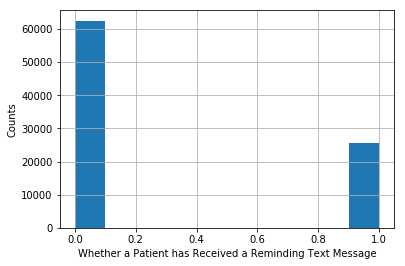

```python
#Let's see the count of people who showed up vs. whether they suffered from Hypertension or not.
df.sms_received[turned_up].hist();
plt.ylabel('Counts');
plt.xlabel('Whether a Patient has Received a Reminding Text Message');
```

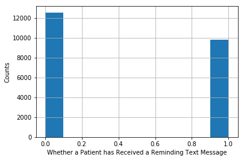

```python
#Let's see the count of people who did not show up vs. whether they suffered from Hypertension or not.
df.sms_received[no_turn_up].hist();
plt.ylabel('Counts');
plt.xlabel('Whether a Patient has Received a Reminding Text Message');
```

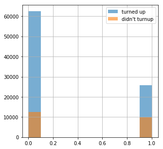

```python
#What about seeing both of these histograms in the same graph?
df.sms_received[turned_up].hist(alpha = 0.6, figsize = (5,5), label = 'turned up');
df.sms_received[no_turn_up].hist(alpha = 0.6, figsize = (5,5), label = "didn't turnup");
plt.legend();
```

```
Text(0.5,1,'Percentage of Patients Showing Up in Reference to Whether They had Received a Reminding SMS Message')
```

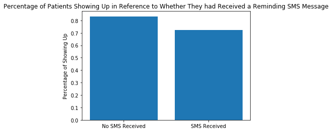

```python
#first, we split the dataset by the 'turned_up' mask which gives us a separate dataframe that only consists of-
#- the patients who showed up.
#Second, we split them into groups charachterized by whether they've received a reminding text message or not, then get the counts for each group.
#Finally, we divide those counts with the total number of samples (of those who showed up and those who didn't),
#to get a normalized ratio!

sms_received_ratio_turnup = df[turned_up].groupby(['sms_received']).size()/df.groupby(['sms_received']).size()
index = ['No SMS Received', 'SMS Received']
height = sms_received_ratio_turnup
plt.bar(index, height)
plt.ylabel('Percentage of Showing Up')
plt.title('Percentage of Patients Showing Up in Reference to Whether They had Received a Reminding SMS Message')
```

```
Text(0.5,1,'Percentage of Patients Not Showing Up in Reference to Whether They Had Received a Reminding SMS Message')
```

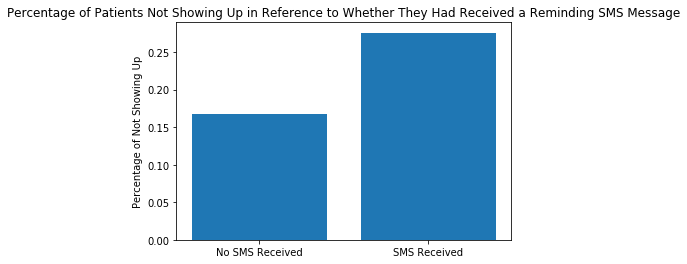

```python
#first, we split the dataset by the 'no_turn_up' mask which gives us a separate dataframe that only consists of-
#- the patients who did not show up.
#Second, we split them into groups charachterized by whether they're suffering from hypertension or not, then get the counts for each group.
#Finally, we divide those counts with the total number of samples (of those who showed up and those who didn't),
#to get a normalized ratio!

sms_received_ratio_no_turnup = df[no_turn_up].groupby(['sms_received']).size()/df.groupby(['sms_received']).size()
index = ['No SMS Received', 'SMS Received']
height = sms_received_ratio_no_turnup
plt.bar(index, height)
plt.ylabel('Percentage of Not Showing Up')
plt.title('Percentage of Patients Not Showing Up in Reference to Whether They Had Received a Reminding SMS Message')
```

There seems to be a correlation between the independent variable of whether a reminding text message has been received and the dependent variable of showing up. The two figures above show that patients who received a reminding text message have a higher probability of not showing up to their scheduled appointments than those who didn't, which was a quite surprising outcome.

## How does the independent variable Time Separating the Date of Scheduling the Appointment and the Appointment Date affect the dependent variable of showing up?

```python
#First, let's add a new column to the data set that calculates the time separating the day of scheduling the appointment-
#and the scheduled date of appointment.
df['time_until_appointment'] = df['appointment_date'] - df['scheduling_date']
df['time_until_appointment']
```

```
0        -1 days +05:21:52
1        -1 days +07:51:33
2        -1 days +07:40:56
3        -1 days +06:30:29
4        -1 days +07:52:37
                ...
110522    34 days 14:44:25
110523    34 days 16:32:27
110524    40 days 07:56:08
110525    40 days 08:50:37
110526    40 days 10:29:04
Name: time_until_appointment, Length: 110526, dtype: timedelta64[ns]
```

I'll print out these 3 columns together to figure out where is the problem coming from.

```python
df[['scheduling_date', 'appointment_date', 'time_until_appointment']]
```

|  | scheduling_date | appointment_date | time_until_appointment |
| --- | --- | --- | --- |
| 0 | 2016-04-29 18:38:08+00:00 | 2016-04-29 00:00:00+00:00 | -1 days +05:21:52 |
| 1 | 2016-04-29 16:08:27+00:00 | 2016-04-29 00:00:00+00:00 | -1 days +07:51:33 |
| 2 | 2016-04-29 16:19:04+00:00 | 2016-04-29 00:00:00+00:00 | -1 days +07:40:56 |
| 3 | 2016-04-29 17:29:31+00:00 | 2016-04-29 00:00:00+00:00 | -1 days +06:30:29 |
| 4 | 2016-04-29 16:07:23+00:00 | 2016-04-29 00:00:00+00:00 | -1 days +07:52:37 |
| 5 | 2016-04-27 08:36:51+00:00 | 2016-04-29 00:00:00+00:00 | 1 days 15:23:09 |
| 6 | 2016-04-27 15:05:12+00:00 | 2016-04-29 00:00:00+00:00 | 1 days 08:54:48 |
| 7 | 2016-04-27 15:39:58+00:00 | 2016-04-29 00:00:00+00:00 | 1 days 08:20:02 |
| 8 | 2016-04-29 08:02:16+00:00 | 2016-04-29 00:00:00+00:00 | -1 days +15:57:44 |
| 9 | 2016-04-27 12:48:25+00:00 | 2016-04-29 00:00:00+00:00 | 1 days 11:11:35 |
| 10 | 2016-04-27 14:58:11+00:00 | 2016-04-29 00:00:00+00:00 | 1 days 09:01:49 |
| 11 | 2016-04-26 08:44:12+00:00 | 2016-04-29 00:00:00+00:00 | 2 days 15:15:48 |
| 12 | 2016-04-28 11:33:51+00:00 | 2016-04-29 00:00:00+00:00 | 0 days 12:26:09 |
| 13 | 2016-04-28 14:52:07+00:00 | 2016-04-29 00:00:00+00:00 | 0 days 09:07:53 |
| 14 | 2016-04-28 10:06:24+00:00 | 2016-04-29 00:00:00+00:00 | 0 days 13:53:36 |
| 15 | 2016-04-26 08:47:27+00:00 | 2016-04-29 00:00:00+00:00 | 2 days 15:12:33 |
| 16 | 2016-04-28 08:51:47+00:00 | 2016-04-29 00:00:00+00:00 | 0 days 15:08:13 |
| 17 | 2016-04-28 09:28:57+00:00 | 2016-04-29 00:00:00+00:00 | 0 days 14:31:03 |
| 18 | 2016-04-26 10:54:18+00:00 | 2016-04-29 00:00:00+00:00 | 2 days 13:05:42 |
| 19 | 2016-04-29 10:43:14+00:00 | 2016-04-29 00:00:00+00:00 | -1 days +13:16:46 |
| 20 | 2016-04-27 07:51:14+00:00 | 2016-04-29 00:00:00+00:00 | 1 days 16:08:46 |
| 21 | 2016-04-27 10:50:45+00:00 | 2016-04-29 00:00:00+00:00 | 1 days 13:09:15 |
| 22 | 2016-04-25 13:29:16+00:00 | 2016-04-29 00:00:00+00:00 | 3 days 10:30:44 |
| 23 | 2016-04-28 10:27:05+00:00 | 2016-04-29 00:00:00+00:00 | 0 days 13:32:55 |
| 24 | 2016-04-29 14:19:19+00:00 | 2016-04-29 00:00:00+00:00 | -1 days +09:40:41 |
| 25 | 2016-04-26 15:04:17+00:00 | 2016-04-29 00:00:00+00:00 | 2 days 08:55:43 |
| 26 | 2016-04-29 14:19:42+00:00 | 2016-04-29 00:00:00+00:00 | -1 days +09:40:18 |
| 27 | 2016-04-27 10:51:45+00:00 | 2016-04-29 00:00:00+00:00 | 1 days 13:08:15 |
| 28 | 2016-04-29 15:48:02+00:00 | 2016-04-29 00:00:00+00:00 | -1 days +08:11:58 |
| 29 | 2016-04-29 15:16:29+00:00 | 2016-04-29 00:00:00+00:00 | -1 days +08:43:31 |
| ... | ... | ... | ... |
| 110497 | 2016-06-01 09:46:33+00:00 | 2016-06-01 00:00:00+00:00 | -1 days +14:13:27 |
| 110498 | 2016-06-08 10:21:14+00:00 | 2016-06-08 00:00:00+00:00 | -1 days +13:38:46 |
| 110499 | 2016-06-01 09:42:56+00:00 | 2016-06-01 00:00:00+00:00 | -1 days +14:17:04 |
| 110500 | 2016-06-08 09:35:13+00:00 | 2016-06-08 00:00:00+00:00 | -1 days +14:24:47 |
| 110501 | 2016-06-01 10:19:12+00:00 | 2016-06-01 00:00:00+00:00 | -1 days +13:40:48 |
| 110502 | 2016-06-08 10:50:42+00:00 | 2016-06-08 00:00:00+00:00 | -1 days +13:09:18 |
| 110503 | 2016-06-01 13:00:36+00:00 | 2016-06-01 00:00:00+00:00 | -1 days +10:59:24 |
| 110504 | 2016-06-08 11:06:21+00:00 | 2016-06-08 00:00:00+00:00 | -1 days +12:53:39 |
| 110505 | 2016-06-01 10:45:50+00:00 | 2016-06-01 00:00:00+00:00 | -1 days +13:14:10 |
| 110506 | 2016-06-01 11:09:20+00:00 | 2016-06-01 00:00:00+00:00 | -1 days +12:50:40 |
| 110507 | 2016-06-08 09:04:18+00:00 | 2016-06-08 00:00:00+00:00 | -1 days +14:55:42 |
| 110508 | 2016-06-01 09:41:00+00:00 | 2016-06-01 00:00:00+00:00 | -1 days +14:19:00 |
| 110509 | 2016-06-08 08:50:51+00:00 | 2016-06-08 00:00:00+00:00 | -1 days +15:09:09 |
| 110510 | 2016-06-01 09:35:48+00:00 | 2016-06-01 00:00:00+00:00 | -1 days +14:24:12 |
| 110511 | 2016-06-08 08:50:20+00:00 | 2016-06-08 00:00:00+00:00 | -1 days +15:09:40 |
| 110512 | 2016-06-08 08:20:01+00:00 | 2016-06-08 00:00:00+00:00 | -1 days +15:39:59 |
| 110513 | 2016-06-08 07:52:55+00:00 | 2016-06-08 00:00:00+00:00 | -1 days +16:07:05 |
| 110514 | 2016-06-08 08:35:31+00:00 | 2016-06-08 00:00:00+00:00 | -1 days +15:24:29 |
| 110515 | 2016-06-06 15:58:05+00:00 | 2016-06-08 00:00:00+00:00 | 1 days 08:01:55 |
| 110516 | 2016-06-07 07:45:16+00:00 | 2016-06-08 00:00:00+00:00 | 0 days 16:14:44 |
| 110517 | 2016-06-07 07:38:34+00:00 | 2016-06-07 00:00:00+00:00 | -1 days +16:21:26 |
| 110518 | 2016-04-27 15:15:06+00:00 | 2016-06-07 00:00:00+00:00 | 40 days 08:44:54 |
| 110519 | 2016-04-27 15:23:14+00:00 | 2016-06-07 00:00:00+00:00 | 40 days 08:36:46 |
| 110520 | 2016-05-03 07:51:47+00:00 | 2016-06-07 00:00:00+00:00 | 34 days 16:08:13 |
| 110521 | 2016-05-03 08:23:40+00:00 | 2016-06-07 00:00:00+00:00 | 34 days 15:36:20 |
| 110522 | 2016-05-03 09:15:35+00:00 | 2016-06-07 00:00:00+00:00 | 34 days 14:44:25 |
| 110523 | 2016-05-03 07:27:33+00:00 | 2016-06-07 00:00:00+00:00 | 34 days 16:32:27 |
| 110524 | 2016-04-27 16:03:52+00:00 | 2016-06-07 00:00:00+00:00 | 40 days 07:56:08 |
| 110525 | 2016-04-27 15:09:23+00:00 | 2016-06-07 00:00:00+00:00 | 40 days 08:50:37 |
| 110526 | 2016-04-27 13:30:56+00:00 | 2016-06-07 00:00:00+00:00 | 40 days 10:29:04 |

110526 rows × 3 columns

There's no hour-data gathered in the column of appointment_date, so I'll have to drop the hour-data gathered in the column of scheduling_date as well.

```python
#Removing the hour-data by extracting the 'date'
df['scheduling_date'] = pd.to_datetime(df['scheduling_date']).dt.date.astype('datetime64[ns]')
df['appointment_date'] = pd.to_datetime(df['appointment_date']).dt.date.astype('datetime64[ns]')
```

```python
#Now let's rerun the commands and see if it did the trick.
df['time_until_appointment'] = df['appointment_date'] - df['scheduling_date']
df['time_until_appointment']
```

```
0         0 days
1         0 days
2         0 days
3         0 days
4         0 days
           ...
110522   35 days
110523   35 days
110524   41 days
110525   41 days
110526   41 days
Name: time_until_appointment, Length: 110526, dtype: timedelta64[ns]
```

Great! Now let's move on to the exploration part.

```
Text(0.5,0,'Time Until the Appointment Comes in Days')
```

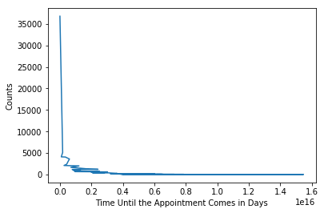

```python
#Let's see the count of people who showed up vs. how many days were left until the appointment.
plt.plot(df.time_until_appointment[turned_up].value_counts())
plt.ylabel('Counts');
plt.xlabel('Time Until the Appointment Comes in Days')
```

```
Text(0.5,0,'Time Until the Appointment Comes in Days')
```

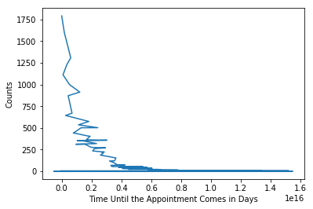

```python
#Let's see the count of people who did not show up vs. how many days were left until the appointment.
plt.plot(df.time_until_appointment[no_turn_up].value_counts())
plt.ylabel('Counts');
plt.xlabel('Time Until the Appointment Comes in Days')
```

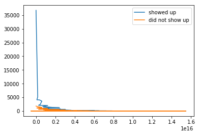

```python
#What about seeing both of these plots in the same graph?
plt.plot(df.time_until_appointment[turned_up].value_counts(), label = 'showed up');
plt.plot(df.time_until_appointment[no_turn_up].value_counts(), label = 'did not show up');
plt.legend();
```

There seems to be no correlation between waiting time and the dependent variable of showing up.